# Lab 8.2 Machine Learning 2 – Artificial Neural Network, Classification

```python
# Let's check the installed tensorflow version
import tensorflow as tf

print('TensorFlow Version is', tf.__version__)
```

```
TensorFlow Version is 2.19.0
```

```python
# required Python packages for this colab
!pip install matplotlib
!pip install pandas
!pip install scipy
!pip install scikit-learn
```

# Training ML model for anomaly detection

Now, you are ready to train ML model. Follow the steps below to create your autoencoder model to predict the anomalous condition of the AFF. In this lab manual, we will use this Colab Notebook. But, you can use this Colab Notefile (ipynb) on your computer using Jupyter Notebook or creating a Python script.

We will reuse the autoencoder training code in [Prelab8.2](https://githubtocolab.com/purduelamm/purdue_me597_iiot/blob/main/lab/lab8/PL8_Colab2.ipynb).

**When you first train the model, please use the given axis, feature, and hyper -parameters to perform Task 2.2. And then, try different combinations.**

### Import TensorFlow and relevant Python packages on your Colab session

```python
# Let's check the installed tensorflow version
import tensorflow as tf

print('TensorFlow Version is', tf.__version__)
```

```
TensorFlow Version is 2.19.0
```

```python
import os
import matplotlib.pyplot as plt
import datetime
import numpy as np
import pandas as pd
from tensorflow import keras
from scipy import stats, fft

from sklearn.metrics import accuracy_score, precision_score, recall_score, roc_curve, auc
from sklearn.model_selection import train_test_split
from tensorflow.keras import layers, losses
from tensorflow.keras.models import Model
```

### Load data

First, upload your training data (Normal and Abnormal) which you collected on the last part to this Colab session.

- Method 1: Upload file on this Colab session (Fast)
- Method 2: Use the code block below (Slow)
- Method 3: Mount your Google Drive if your data is in it (Fast)

```python
#This code allows you to upload a file from your local drive
from google.colab import files
uploaded = files.upload()
```

```
Saving 20260328_163238_Normal_lab8_data.csv to 20260328_163238_Normal_lab8_data (1).csv
Saving 20260328_165656_Abnormal_lab8_data.csv to 20260328_165656_Abnormal_lab8_data (1).csv
```

```python
## Loading data using pandas

normal_data_file = "20260328_163238_Normal_lab8_data.csv" # normal condition filename: You must change this!
abnormal_data_file = "20260328_165656_Abnormal_lab8_data.csv" # abnormal condition filename: You must change this!

df_normal = pd.read_csv(normal_data_file) # normal dataframe
df_abnormal = pd.read_csv(abnormal_data_file) # abnormal dataframe

frames = [df_normal, df_abnormal] # frame list to merge two dataframes into one

df = pd.concat(frames) # new concatenated dataframe

df # display dataframe
```

|  | Condition | Xacc array [m/s2] | Yacc array [m/s2] | Zacc array [m/s2] |
| --- | --- | --- | --- | --- |
| 0 | Normal | 0.0 0.2353596 0.0 -0.6276256 0.0 0.0 0.0 0.549... | -0.4707192 1.0983448 -0.2353596 0.0 0.2353596 ... | 10.591182 8.7867584 11.6110736 10.591182 9.492... |
| 1 | Normal | 0.2353596 -0.6276256 -0.4707192 0.5491724 -0.5... | 0.0784532 1.0198916 -0.392266 -0.1569064 0.078... | 9.1790244 10.0420096 8.7083052 10.8265416 9.25... |
| 2 | Normal | 0.2353596 0.0 -0.2353596 0.6276256 -0.5491724 ... | 0.9414384 0.5491724 -0.0784532 -1.2552512 0.0 ... | 9.492837199999999 9.9635564 11.2972608 9.02211... |
| 3 | Normal | 0.0 0.392266 -0.0784532 0.0 0.392266 0.0 0.235... | -0.1569064 0.0784532 -0.8629851999999999 0.078... | 8.629852 8.7867584 9.649743599999999 9.9635564... |
| 4 | Normal | 0.784532 0.4707192 0.0 0.0 0.0 0.0 0.0 -0.3922... | -0.6276256 0.3138128 -0.392266 0.6276256 1.176... | 10.4342756 8.8652116 11.924886399999998 9.1790... |
| ... | ... | ... | ... | ... |
| 295 | Abnormal | 0.0 0.2353596 0.5491724 -0.7060788 0.2353596 2... | 3.4519407999999996 4.6287388 6.4331624 3.13812... | 11.2188076 10.8265416 9.022118 10.277369199999... |
| 296 | Abnormal | 0.0 -1.1767979999999998 -1.3337044 -1.3337044 ... | 1.4121576 2.9812215999999996 3.373487600000000... | 7.609960399999999 6.354709199999999 9.1790244 ... |
| 297 | Abnormal | -0.3138128 -0.3138128 -0.784532 -1.2552512 -1.... | -0.8629851999999999 0.0 -0.5491724 1.2552512 4... | 7.139241199999999 9.3359308 9.2574776 11.21880... |
| 298 | Abnormal | -0.6276256 -1.8828768 -2.2751428 -1.2552512 -0... | 3.138128 2.9812215999999996 2.5105024 4.158019... | 9.1790244 11.1403544 9.7281968 8.3944923999999... |
| 299 | Abnormal | -1.569064 -1.8828768 -1.3337044 0.2353596 0.23... | 4.8640984 5.1779112 2.9027684 4.314926 1.64751... | 6.982334799999999 6.982334799999999 9.8851032 ... |

600 rows × 4 columns

### Data Transformation

The strategy to build this model is to select, one by one, data from each axis and access which axis helps the model classify with better accuracy and precision.

Let's start with the X-axis: Assign the X-axis on the variable AXIS on the code below.

```python
## Data Transformation
# X-axis: 'Xacc array [m/s2]'
# Y-axis: 'Yacc array [m/s2]'
# Z-axis: 'Zacc array [m/s2]'
AXIS = 'Xacc array [m/s2]' # in this case, X-axis acceleration data

# Exploding the values contained in selected column and converting the string values into float values
df_new = pd.concat([df['Condition'],df[AXIS].str.split(' ', expand=True).astype(float)], axis=1) # transform space delimited array to each value
ds = df_new.copy() # make ds by copying df
```

Now, we change the labels 'Normal' and 'Abnormal' into binary notation for the model usage.

```python
#Converting the Classifier into binary values
ds.loc[df['Condition'] == 'Normal', 'Status'] = 1 # if Condition column is 'Normal', Give 'Status' Column 1
ds.loc[df['Condition'] == 'Abnormal', 'Status'] = 0 # if Condition column is 'Abnormal', Give 'Status' Column 0
ds.drop('Condition', axis=1, inplace=True) # drop 'Condition' column (the first column)

ds # display ds (dataset)
```

|  | 0 | 1 | 2 | 3 | 4 | 5 | 6 | 7 | 8 | 9 | ... | 991 | 992 | 993 | 994 | 995 | 996 | 997 | 998 | 999 | Status |
| --- | --- | --- | --- | --- | --- | --- | --- | --- | --- | --- | --- | --- | --- | --- | --- | --- | --- | --- | --- | --- | --- |
| 0 | 0.000000 | 0.235360 | 0.000000 | -0.627626 | 0.000000 | 0.000000 | 0.000000 | 0.549172 | 0.156906 | 0.784532 | ... | 0.000000 | -0.627626 | 0.156906 | 0.000000 | 0.000000 | 0.000000 | 0.000000 | -0.627626 | 0.549172 | 1.0 |
| 1 | 0.235360 | -0.627626 | -0.470719 | 0.549172 | -0.549172 | 0.000000 | -0.392266 | -0.706079 | 0.000000 | 0.000000 | ... | -0.392266 | -0.627626 | 0.000000 | 0.000000 | 0.000000 | -0.706079 | -0.078453 | 0.078453 | 0.000000 | 1.0 |
| 2 | 0.235360 | 0.000000 | -0.235360 | 0.627626 | -0.549172 | 0.313813 | 0.078453 | -0.235360 | 0.156906 | -0.313813 | ... | 0.000000 | 0.078453 | 0.078453 | -0.862985 | 0.000000 | 0.078453 | 0.313813 | -0.470719 | 0.862985 | 1.0 |
| 3 | 0.000000 | 0.392266 | -0.078453 | 0.000000 | 0.392266 | 0.000000 | 0.235360 | -0.470719 | -0.156906 | 0.784532 | ... | 0.000000 | -0.627626 | 0.470719 | -0.078453 | 0.549172 | -0.784532 | 0.627626 | 0.470719 | -0.392266 | 1.0 |
| 4 | 0.784532 | 0.470719 | 0.000000 | 0.000000 | 0.000000 | 0.000000 | 0.000000 | -0.392266 | 0.470719 | -0.549172 | ... | -0.392266 | -0.078453 | 0.000000 | -0.549172 | -0.235360 | -0.156906 | 0.000000 | -0.627626 | 0.549172 | 1.0 |
| ... | ... | ... | ... | ... | ... | ... | ... | ... | ... | ... | ... | ... | ... | ... | ... | ... | ... | ... | ... | ... | ... |
| 295 | 0.000000 | 0.235360 | 0.549172 | -0.706079 | 0.235360 | 2.039783 | 2.039783 | -0.862985 | -1.019892 | -0.941438 | ... | 1.176798 | -0.078453 | -1.569064 | -0.156906 | 0.392266 | 1.490611 | 0.784532 | 0.549172 | 0.000000 | 0.0 |
| 296 | 0.000000 | -1.176798 | -1.333704 | -1.333704 | -0.784532 | -0.706079 | 0.235360 | 0.000000 | 0.941438 | 1.019892 | ... | 0.470719 | 0.941438 | 0.156906 | 1.176798 | 0.000000 | -0.627626 | 0.470719 | 2.118236 | 1.412158 | 0.0 |
| 297 | -0.313813 | -0.313813 | -0.784532 | -1.255251 | -1.098345 | -1.882877 | -1.255251 | 0.000000 | -0.549172 | 0.784532 | ... | -0.470719 | -0.706079 | -0.627626 | 0.392266 | 1.882877 | 0.078453 | 0.235360 | -0.470719 | 0.313813 | 0.0 |
| 298 | -0.627626 | -1.882877 | -2.275143 | -1.255251 | -0.235360 | 0.000000 | 0.235360 | 1.490611 | 1.176798 | -0.235360 | ... | -0.078453 | 0.784532 | 1.569064 | 0.862985 | 0.078453 | 0.235360 | 1.098345 | 0.470719 | 0.000000 | 0.0 |
| 299 | -1.569064 | -1.882877 | -1.333704 | 0.235360 | 0.235360 | 0.078453 | 0.392266 | -0.078453 | -0.392266 | 0.392266 | ... | 0.000000 | 0.078453 | 1.804424 | 1.804424 | 0.000000 | 0.549172 | 0.313813 | 0.784532 | -0.627626 | 0.0 |

600 rows × 1001 columns

### Training data pipe-line

We just loaded data and transformed it. Let's start creating input data pipe-line for training the model.

Define data, raw data and labels.

```python
data = ds.values
# Define Raw data W/O signal processing
raw_data = data[:,:-1]
# Labels: The last column
labels = data[:,-1]
```

Here is the signal processing part. Time domain and frequency domain will be used for training the model.

Using the signal processing, you can define the time domain feature and frequency domain feature, respectively.

```python
## signal processing
# Time-domain data
def timeFeatures(data):
    feature = [] # initialize feature list
    for i in range(len(data)):
        mean = np.mean(data[i]) # mean
        std = np.std(data[i]) # standard deviation
        rms = np.sqrt(np.mean(data[i] ** 2)) # root mean squre
        peak = np.max(abs(data[i])) # peak
        skew = stats.skew(data[i]) # skewness
        kurt = stats.kurtosis(data[i]) # kurtosis
        cf = peak/rms # crest factor
        # number of feature of each measurement = 7
        feature.append(np.array([mean,std,rms,peak,skew,kurt,cf], dtype=float))
    feature = np.array(feature)
    return feature # feature list, each element is numpy array with datatype float

# DFT magnitude data
def freqFeatures(data):
    feature = []
    for i in range(len(data)):
        N = len(data[i]) # number of data
        yf = 2/N*np.abs(fft.fft(data[i])[:N//2]) # yf is DFT signal magnitude
        yf[0] = 0
        feature.append(np.array(yf))
    feature = np.array(feature)
    return feature


time_data = timeFeatures(raw_data) # define time domain feature
freq_data = freqFeatures(raw_data) # define frequency domain feature (DFT)
```

Here is data (feature) selection and split part.

```python
## Data (feature) selection and Split training and validation dataset
# Feature selection
input_feature = raw_data # raw data input without any signal processing
# input_feature = time_data # time domain data
# input_feature = freq_data # frequency data

# get training and test (validation) dataset
train_data, test_data, train_labels, test_labels = train_test_split(
    input_feature, labels, test_size=0.2, random_state=20
)
```

Normalization based on a min/max scaling is done here to support the learning objective of the autoencoder (minimizing reconstruction error) and makes the results more interpretable.

```python
## Data normalization

def tensorNormalization(data): # data as numpy array
    min_val = tf.reduce_min(data) # get min val
    max_val = tf.reduce_max(data) # get max val
    data_normal = (data - min_val) / (max_val - min_val) # get normalized data as numpy array
    return tf.cast(data_normal, tf.float32) # tensorarray, float 32 datatype

train_data = tensorNormalization(train_data) # Normalizing train data
test_data = tensorNormalization(test_data) # Normalizing test data
```

You will train the autoencoder using only the normal rhythms, which are labeled in the dataset as 1. Separate the normal vibrations from the abnormal vibrations. **You have to make sure of the size/dimension of feature array.**

```python
#Splitting the dataset based on classification: train_labels: Normal, ~train_labels: Abnormal
train_labels = train_labels.astype(bool) # transform labels as bool (True or False)
test_labels = test_labels.astype(bool) # in case of 'Normal' it is Ture, if not, False

normal_train_data = train_data[train_labels] # define normal train data
normal_test_data = test_data[test_labels] # define normal test data

anomalous_train_data = train_data[~train_labels] # define abnormal train data
anomalous_test_data = test_data[~test_labels] # define abnormal test data

portion_of_anomaly_in_training = 0.1 #10% of training data will be anomalies
end_size = int(len(normal_train_data)/(10-portion_of_anomaly_in_training*10))
combined_train_data = np.append(normal_train_data, anomalous_test_data[:end_size], axis=0)
N_feature = combined_train_data.shape[1] # get the Number of feature, it depends on your input feature!
print("Number of training dataset is {}.".format(combined_train_data.shape))
print("Number of feature is {}.".format(N_feature))
```

```
Number of training dataset is (260, 1000).
Number of feature is 1000.
```

Plot a normal vibration feature

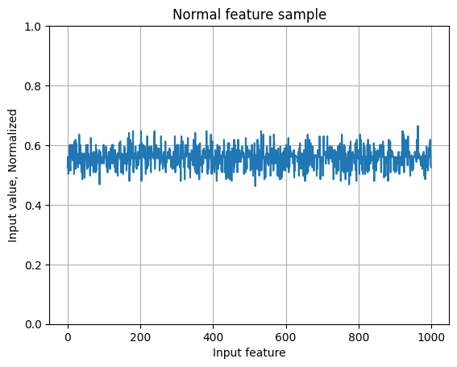

```python
#Plotting sample of normal data
plt.grid()
plt.plot(np.arange(N_feature), normal_train_data[0])
plt.title("Normal feature sample")
plt.ylim([0, 1])
plt.xlabel("Input feature")
plt.ylabel("Input value, Normalized")
plt.show()
```

Plot a abnomalous vibration feature

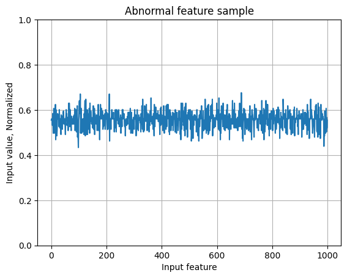

```python
#Plotting sample of anomalous data
plt.grid()
plt.plot(np.arange(N_feature), anomalous_train_data[0])
plt.title("Abnormal feature sample")
plt.ylim([0, 1])
plt.xlabel("Input feature")
plt.ylabel("Input value, Normalized")
plt.show()
```

### Task 2.1

What differences do you notice between the normal and anomalous plots? Can you figure out anomaly based on the siganl/feature?

The abnormal data seems to have a higher amplitude and a faster amplitude than the normal data. However the graphs are very similar since this is based on the X-axis data and likely would change if a different axis was used.

### Autoencoder model training

Changing the size of the embedding (latent space) can produce interesting results. Try to play around with that layer size by assigning a value to the variable EMBEDDING_SIZE.

```python
## Creating the artificial neural network using autoencoder
EMBEDDING_SIZE = 64 #Define how many neurons in the inner layer   <-----------------------------------------------------------------------------
class AnomalyDetector(Model):
  def __init__(self):
    super(AnomalyDetector, self).__init__()
    self.encoder = tf.keras.Sequential([
      layers.Dense(256, activation="relu"),
      layers.Dense(128, activation="relu"),
      layers.Dense(EMBEDDING_SIZE, activation="relu")]) # Smallest Layer Defined Here

    self.decoder = tf.keras.Sequential([
      layers.Dense(128, activation="relu"),
      layers.Dense(256, activation="relu"),
      layers.Dense(N_feature, activation="sigmoid")])

  def call(self, x):
    encoded = self.encoder(x)
    decoded = self.decoder(encoded)
    return decoded

autoencoder = AnomalyDetector() # define autoencoder model class
print("Chosen Embedding Size: ", EMBEDDING_SIZE)
# opt = keras.optimizers.Adam(learning_rate=0.0001) # default learning rate is 0.001, if you want, you can change learning rate.
# autoencoder.compile(optimizer=opt, loss='mae')
autoencoder.compile(optimizer='adam', loss='mae')
```

```
Chosen Embedding Size:  64
```

### Training the model

Note that the autoencoder is trained using only the normal data, but is evaluated using the full test set.

```python
#Training the model
history = autoencoder.fit(normal_train_data, normal_train_data,
          epochs=100,
          batch_size=100,
          validation_data=(test_data, test_data),
          shuffle=True)
```

```
3/3 ━━━━━━━━━━━━━━━━━━━━ 2s 126ms/step - loss: 0.0700 - val_loss: 0.0774
3/3 ━━━━━━━━━━━━━━━━━━━━ 0s 45ms/step - loss: 0.0597 - val_loss: 0.0764
3/3 ━━━━━━━━━━━━━━━━━━━━ 0s 46ms/step - loss: 0.0505 - val_loss: 0.0770
3/3 ━━━━━━━━━━━━━━━━━━━━ 0s 46ms/step - loss: 0.0461 - val_loss: 0.0762
3/3 ━━━━━━━━━━━━━━━━━━━━ 0s 45ms/step - loss: 0.0445 - val_loss: 0.0794
3/3 ━━━━━━━━━━━━━━━━━━━━ 0s 52ms/step - loss: 0.0440 - val_loss: 0.0785
3/3 ━━━━━━━━━━━━━━━━━━━━ 0s 46ms/step - loss: 0.0437 - val_loss: 0.0765
3/3 ━━━━━━━━━━━━━━━━━━━━ 0s 46ms/step - loss: 0.0434 - val_loss: 0.0771
3/3 ━━━━━━━━━━━━━━━━━━━━ 0s 45ms/step - loss: 0.0431 - val_loss: 0.0777
3/3 ━━━━━━━━━━━━━━━━━━━━ 0s 46ms/step - loss: 0.0429 - val_loss: 0.0778
3/3 ━━━━━━━━━━━━━━━━━━━━ 0s 45ms/step - loss: 0.0427 - val_loss: 0.0778
3/3 ━━━━━━━━━━━━━━━━━━━━ 0s 45ms/step - loss: 0.0426 - val_loss: 0.0766
3/3 ━━━━━━━━━━━━━━━━━━━━ 0s 45ms/step - loss: 0.0428 - val_loss: 0.0768
3/3 ━━━━━━━━━━━━━━━━━━━━ 0s 53ms/step - loss: 0.0427 - val_loss: 0.0766
3/3 ━━━━━━━━━━━━━━━━━━━━ 0s 44ms/step - loss: 0.0427 - val_loss: 0.0764
3/3 ━━━━━━━━━━━━━━━━━━━━ 0s 45ms/step - loss: 0.0427 - val_loss: 0.0766
3/3 ━━━━━━━━━━━━━━━━━━━━ 0s 44ms/step - loss: 0.0427 - val_loss: 0.0772
3/3 ━━━━━━━━━━━━━━━━━━━━ 0s 46ms/step - loss: 0.0425 - val_loss: 0.0773
3/3 ━━━━━━━━━━━━━━━━━━━━ 0s 45ms/step - loss: 0.0425 - val_loss: 0.0774
3/3 ━━━━━━━━━━━━━━━━━━━━ 0s 46ms/step - loss: 0.0424 - val_loss: 0.0771
3/3 ━━━━━━━━━━━━━━━━━━━━ 0s 44ms/step - loss: 0.0425 - val_loss: 0.0772
3/3 ━━━━━━━━━━━━━━━━━━━━ 0s 49ms/step - loss: 0.0425 - val_loss: 0.0773
3/3 ━━━━━━━━━━━━━━━━━━━━ 0s 44ms/step - loss: 0.0425 - val_loss: 0.0768
3/3 ━━━━━━━━━━━━━━━━━━━━ 0s 46ms/step - loss: 0.0425 - val_loss: 0.0769
3/3 ━━━━━━━━━━━━━━━━━━━━ 0s 44ms/step - loss: 0.0425 - val_loss: 0.0769
3/3 ━━━━━━━━━━━━━━━━━━━━ 0s 46ms/step - loss: 0.0424 - val_loss: 0.0770
3/3 ━━━━━━━━━━━━━━━━━━━━ 0s 45ms/step - loss: 0.0424 - val_loss: 0.0769
3/3 ━━━━━━━━━━━━━━━━━━━━ 0s 47ms/step - loss: 0.0424 - val_loss: 0.0766
3/3 ━━━━━━━━━━━━━━━━━━━━ 0s 86ms/step - loss: 0.0425 - val_loss: 0.0774
3/3 ━━━━━━━━━━━━━━━━━━━━ 0s 81ms/step - loss: 0.0424 - val_loss: 0.0776
3/3 ━━━━━━━━━━━━━━━━━━━━ 0s 79ms/step - loss: 0.0423 - val_loss: 0.0776
3/3 ━━━━━━━━━━━━━━━━━━━━ 0s 64ms/step - loss: 0.0423 - val_loss: 0.0776
3/3 ━━━━━━━━━━━━━━━━━━━━ 0s 77ms/step - loss: 0.0424 - val_loss: 0.0774
3/3 ━━━━━━━━━━━━━━━━━━━━ 0s 87ms/step - loss: 0.0423 - val_loss: 0.0775
3/3 ━━━━━━━━━━━━━━━━━━━━ 0s 68ms/step - loss: 0.0424 - val_loss: 0.0779
3/3 ━━━━━━━━━━━━━━━━━━━━ 0s 69ms/step - loss: 0.0423 - val_loss: 0.0777
3/3 ━━━━━━━━━━━━━━━━━━━━ 0s 72ms/step - loss: 0.0422 - val_loss: 0.0776
3/3 ━━━━━━━━━━━━━━━━━━━━ 0s 69ms/step - loss: 0.0422 - val_loss: 0.0778
3/3 ━━━━━━━━━━━━━━━━━━━━ 0s 92ms/step - loss: 0.0422 - val_loss: 0.0776
3/3 ━━━━━━━━━━━━━━━━━━━━ 0s 76ms/step - loss: 0.0422 - val_loss: 0.0772
```

[output cut: 45 more lines]

```
3/3 ━━━━━━━━━━━━━━━━━━━━ 0s 46ms/step - loss: 0.0376 - val_loss: 0.0762
3/3 ━━━━━━━━━━━━━━━━━━━━ 0s 46ms/step - loss: 0.0377 - val_loss: 0.0764
3/3 ━━━━━━━━━━━━━━━━━━━━ 0s 46ms/step - loss: 0.0371 - val_loss: 0.0756
3/3 ━━━━━━━━━━━━━━━━━━━━ 0s 45ms/step - loss: 0.0371 - val_loss: 0.0774
3/3 ━━━━━━━━━━━━━━━━━━━━ 0s 46ms/step - loss: 0.0380 - val_loss: 0.0761
3/3 ━━━━━━━━━━━━━━━━━━━━ 0s 49ms/step - loss: 0.0379 - val_loss: 0.0759
3/3 ━━━━━━━━━━━━━━━━━━━━ 0s 45ms/step - loss: 0.0374 - val_loss: 0.0758
3/3 ━━━━━━━━━━━━━━━━━━━━ 0s 46ms/step - loss: 0.0373 - val_loss: 0.0758
3/3 ━━━━━━━━━━━━━━━━━━━━ 0s 45ms/step - loss: 0.0378 - val_loss: 0.0760
3/3 ━━━━━━━━━━━━━━━━━━━━ 0s 43ms/step - loss: 0.0374 - val_loss: 0.0754
3/3 ━━━━━━━━━━━━━━━━━━━━ 0s 44ms/step - loss: 0.0368 - val_loss: 0.0754
3/3 ━━━━━━━━━━━━━━━━━━━━ 0s 46ms/step - loss: 0.0361 - val_loss: 0.0751
3/3 ━━━━━━━━━━━━━━━━━━━━ 0s 52ms/step - loss: 0.0370 - val_loss: 0.0754
3/3 ━━━━━━━━━━━━━━━━━━━━ 0s 48ms/step - loss: 0.0360 - val_loss: 0.0748
3/3 ━━━━━━━━━━━━━━━━━━━━ 0s 46ms/step - loss: 0.0358 - val_loss: 0.0756
```

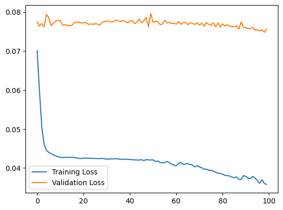

```python
#Plotting the evolution of training and validation loss
plt.plot(history.history["loss"], label="Training Loss")
plt.plot(history.history["val_loss"], label="Validation Loss")
plt.legend()
```